# Boosting

## Where we left off

- **Day 17:** many full trees, each on a bootstrap sample, **vote**.
  - Bagging 16.4%, random forest 15.0% (one tree: 18.2%).
  - The trees are grown **independently**: no tree knows what the others got wrong.
- **Today: boosting** (ISL 8.2.3).
  - Grow trees **one after another**, each fixing what the trees so far get wrong.
  - Small trees, small steps.

## The idea: learn slowly

**Boosting a regression tree** (ISL Algorithm 8.2). Example: a student’s **debt in dollars** from family income (Yes/No comes later).

- Start with a simple model: predict the **average** for everyone. (ISL starts at 0; R’s boosting package, `gbm`, starts at the average. Same idea.)
- Repeat \(B\) times:
  - **Residual** for each student = actual − model’s prediction: what the model still gets wrong.
  - Fit a **small** tree (\(d\) splits) to the residuals, not to the outcome.
  - Add a shrunken copy of it: new model = model + \(\lambda\) × tree.
- Final model: the start plus all \(B\) shrunken trees. Each is weak alone; together they build a flexible fit.

## Step 1: start with the average

> **A cleaned-up version of Day 15’s debt pattern: 50 students, little noise.**

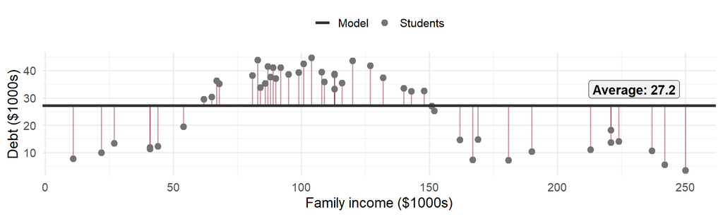

- Vertical lines = **residuals** (actual − prediction). Above the line: under-predicted; below: over-predicted.
- MSE (the average squared residual) = 171.4.

## Step 2: tree 1 fits the residuals

> **Plot the residuals, not the debt. Where is the model most wrong?**

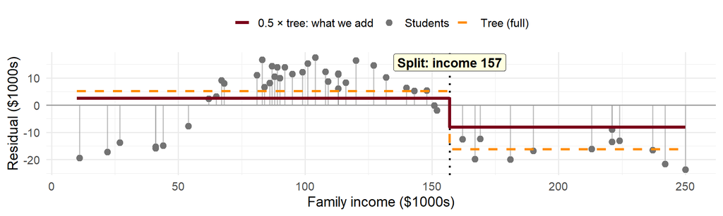

- Tree 1 (a stump) finds the best single split **of the residuals** and predicts their average on each side: 5.1 below income 157, -16.2 above.
- We add only \(\lambda\) = 0.5 of it: 2.6 and -8.1.

## Step 3: update the model

> **New model = average + 0.5 × tree 1.** MSE 171.4 → 109.0.

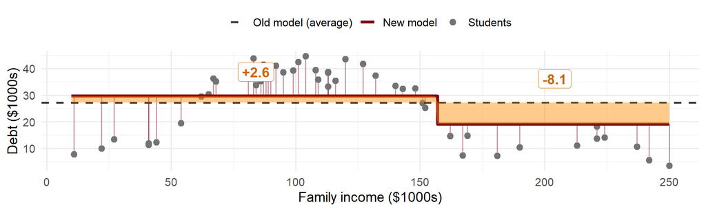

- Orange: the change. Below income 157 the model moves **up**, above it **down**. The vertical lines are now the **new residuals**.
- Why only half? A full step would trust this one split completely; smaller steps leave room for later trees. (In practice: 0.01.)

## Step 3, by the numbers

> **A few of the 50 students** ($1000s).

| Family income | Actual debt | Start (average) | Tree 1 says | New model = start + 0.5 × tree | Improvement in squared error |
| --- | --- | --- | --- | --- | --- |
| 54 | **19.5** | 27.2 | 5.1 | 27.2 + 0.5 × (5.1) = **29.7** | -45.8 |
| 86 | **35.3** | 27.2 | 5.1 | 27.2 + 0.5 × (5.1) = **29.7** | 35.2 |
| 162 | **14.6** | 27.2 | -16.2 | 27.2 + 0.5 × (-16.2) = **19.0** | 137.9 |
| **Average, all 50** | **27.2** | 27.2 |  | **27.2** | **62.4** |

- Students on the same side of the split get the **same** push: the average residual there, not their own. The $54k student is over-predicted, yet still goes up.
- No single round fixes anyone. The next tree looks at the new residuals.

## Step 4: tree 2 fits what’s left

> **Residuals after step 3. Where is the model most wrong now?**

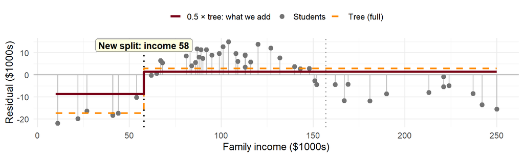

- Tree 2 splits somewhere **new** (income 58; tree 1 used 157): the lowest incomes are still over-predicted.
- Again we add only half of it.

## Step 5: after 2 trees

> **New model = average + 0.5 × tree 1 + 0.5 × tree 2.** MSE 171.4 → 109.0 → 72.0.

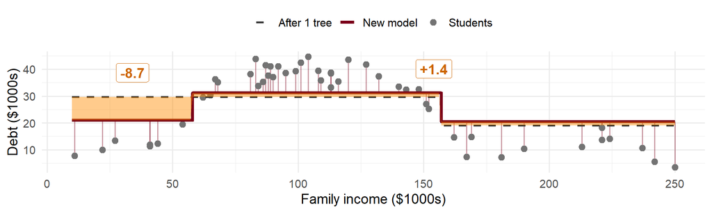

- Tree 1 found the high-income edge (157), tree 2 the low-income edge (58): the **hump** is starting to form. Middle incomes borrow the most.
- Repeat \(B\) times: each tree takes a small step where the residuals point.

## Watch it learn

> **Day 15’s debt ($1000s) vs income, SAT 1150–1390. Stumps, \(\lambda\) = 0.1.**

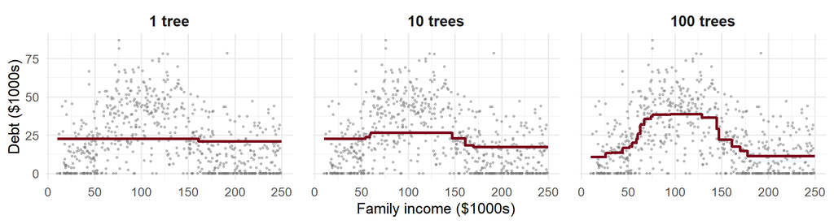

- After 1 tree: the average plus 10% of one split. After 100: close to the data.
- Each round, the biggest leftover pattern gets the next split: first the hump, then the finer steps.

## Three tuning parameters

| Tuning parameter | In gbm() | Too small | Too large | Usual choice |
| --- | --- | --- | --- | --- |
| *B*: number of trees | `n.trees` | Underfits: the model is still close to the average | **Overfits**: later trees fit noise | Pick with **CV** |
| *λ*: shrinkage (step size) | `shrinkage` | Learns slowly: **needs a large *B*** | Big steps chase noise; overfits after few trees | 0.01 or 0.001 |
| *d*: splits per tree | `interaction.depth` | *d* = 1 (a **stump**): no interactions. Fine if there are none | Each tree fits more; overfits sooner | 1 or 2 |

- They work together: a smaller *λ* needs a larger *B*.
- Why small steps? One big correction chases the noise in this training set. Many small ones let each tree catch only the strongest leftover pattern, and let later trees fix earlier mistakes.

## Boosting vs a forest

|  | Random forest (Day 17) | Boosting |
| --- | --- | --- |
| What each tree is fit to | The **outcome**, on a bootstrap sample | The **residuals** of the model so far |
| Does a tree know about the others? | No: grown independently (in any order) | **Yes**: each one depends on all the earlier ones |
| Size of each tree | Full: low bias, high variance | Small (*d* = 1 or 2 splits): high bias, low variance |
| How they’re combined | **Average** (vote) | **Sum**, each shrunk by *λ* |
| What it fixes | Variance | Bias, a little at a time |
| Tuning | **Little**: defaults work well; more trees never hurt | **More**: *B*, *λ*, and *d* all matter; too many trees can overfit |

- A forest asks 500 trees the same question and averages. Boosting asks each tree about what’s **left over**.

## Boosting a Yes/No outcome

> **Heavy debt = 1, no heavy debt = 0. Residual = outcome − predicted probability.** (Three students; λ = 0.01, d = 2.)

| Student | Heavy debt? | P(heavy debt), 100 trees | Residual | P(heavy debt), 2,000 trees |
| --- | --- | --- | --- | --- |
| A | Yes (1) | 0.21 | 0.79 | 0.94 |
| B | No (0) | 0.49 | -0.49 | 0.09 |
| C | Yes (1) | 0.54 | 0.46 | 0.96 |

- Start: everyone gets 0.31, the share with heavy debt. With \(\lambda\) = 0.01, 100 trees haven’t moved far.
- Positive residuals (A, C: probability too low) → later trees push **up**; negative (B) → **down**.
- `gbm` adds the trees on the **log-odds** scale, as in logistic regression, so probabilities stay between 0 and 1 (`distribution = "bernoulli"`).

## Boosting **can** overfit

> **CV error as trees are added.** Color: \(\lambda\). Line: \(d\). Circles: each line’s best \(B\).

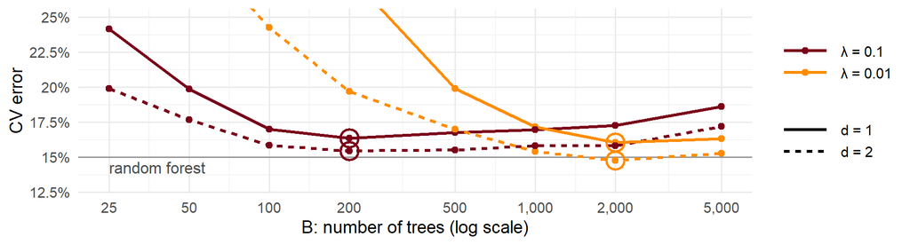

## Why do the trees need 2 splits?

> **Best CV error for each setting.**

| Splits per tree, d | Shrinkage, λ | Best B | CV error |
| --- | --- | --- | --- |
| 1 | 0.01 | 2,000 | 16.0% (SE 0.7) |
| 2 | 0.01 | 2,000 | 14.8% (SE 0.6) |
| 1 | 0.1 | 200 | 16.4% (SE 0.7) |
| 2 | 0.1 | 200 | 15.4% (SE 0.6) |

- A stump asks about **one** predictor, so the model adds up separate effects of income, SAT, …
- The staircase is about income **and** SAT together: SAT matters differently at each income level. Two splits per tree can capture that.

## The full comparison

> **Same 5 folds, all 10 predictors.** CV error rate (lower is better).

| Model | CV error |
| --- | --- |
| Logistic regression | 22.8% (SE 0.6) |
| KNN, K = 25 | 21.8% (SE 0.6) |
| Pruned tree, 5 leaves (one-SE rule) | 18.2% (SE 0.9) |
| Bagging, 500 trees (Day 17) | 16.4% (SE 0.5) |
| Random forest, 500 trees (Day 17) | 15.0% (SE 0.6) |
| **Boosting, d = 2, λ = 0.01, B = 2,000** | **14.8% (SE 0.6)** |

## In R

```r
library(gbm)
students01 <- students %>%
  mutate(y = if_else(heavy_debt == "Yes", 1, 0)) %>%   # gbm wants a 0/1 outcome
  select(-heavy_debt)
boost <- gbm(y ~ ., data = students01,
             distribution = "bernoulli",               # Yes/No outcome
             n.trees = 2000,                           # B
             shrinkage = 0.01,                         # lambda
             interaction.depth = 2)                    # d
prob <- predict(boost, new_students, n.trees = 2000, type = "response")
pred <- if_else(prob > 0.5, "Yes", "No")
```

- `predict(..., n.trees = c(100, 500, 2000))` scores several values of \(B\) from one fit.

## Boosting in practice today

> **XGBoost**, **LightGBM**, **CatBoost**: the usual first choice for data in a table. Same idea, a few additions.

|  | Today (gbm) | XGBoost, LightGBM, CatBoost |
| --- | --- | --- |
| Each tree | Fits the residuals; add λ × the tree | **Same** |
| Tree size | Small: *d* = 1 or 2 | A bit bigger (about 6 levels, or ~30 leaves) |
| Choosing *B* | CV over a grid of *B* | **Early stopping:** add trees until error on held-out data stops falling |
| Overfitting | Small *λ*, tune *B* | Also a **penalty** on big leaf values, and each tree sees a random subset of predictors (like `mtry`) |
| Speed | Fine for thousands of rows | Millions of rows: groups each predictor into bins before searching for splits |

- Used for credit scoring, fraud detection, search ranking; often beats neural networks on tables.
- R packages `xgboost`, `lightgbm`: `eta` = *λ*, `max_depth` = *d*, `nrounds` = *B*.

## Summary

- **Boosting:** start at the average; each small tree fits the **residuals** of the model so far; add \(\lambda\) × the tree.
- Three tuning parameters: \(B\) (too many overfits), \(\lambda\) (small = slow, needs large \(B\)), \(d\) (1 = no interactions).
- Choose them with **CV**, like tree size on Day 16.
- On the debt data, boosting and the random forest tie, and both beat one tree by about 3 points. Neither can be read like a tree.
- **Next:** unsupervised learning, starting with clustering.

## For rest of class

- Work on the `day18_activity`
  - new data: simulated patients with 10 yes/no risk factors (smoker, high blood pressure, …). Is a patient at risk?
  - boost by hand with stumps, then tune *B*, *λ*, and *d* with CV
  - compare boosting with one tree, bagging, and a random forest, and find out **why** one of them wins
- Ask me questions if you run into issues